# Advertising_and_Sales

## Anúncio x Vendas

**Author :** Alcides Gabriel

**E-mail :** alcidesgabriel.ds@gmail.com

**Task :** Analisar os resultados de como a combinação de anúncios em rádio, TV e jornais resultaram nas vendas e desenvolver dois modelos de machine learning, um complexo e um simples, com o intuito de comparar como esses modelos irão performar com uma base de dados simples.

[Fonte de dados: Kaggle](https://www.kaggle.com/datasets/yasserh/advertising-sales-dataset)

# Importação

```python
# Básico
import pandas as pd
import numpy as np
import matplotlib.pyplot as plt
import seaborn as sns
import matplotlib.gridspec as gridspec
from matplotlib.collections import LineCollection
from matplotlib.colors import ListedColormap, BoundaryNorm
import time

# Bibliotecas de Machine Learning
from sklearn.preprocessing import LabelEncoder, MinMaxScaler
from sklearn.model_selection import KFold
import tensorflow.keras as keras
from tensorflow.keras.layers import Dense
from sklearn.metrics import r2_score, mean_squared_error
from sklearn.linear_model import LinearRegression
from sklearn.preprocessing import PolynomialFeatures
```

```python
dataset = pd.read_csv('/content/drive/MyDrive/Colab Assuntos Exemplos/Regressão/Advertising and sales/Advertising Budget and Sales.csv', index_col=0)
```

# Exploração dos Dados

- Antes de elaborar um modelo de machine learning para previsão é necessário entender como são esses dados de entrada, isso é necessário para saber se algumas alterações devem ser feitas nos dados como remoção de informações erradas ou preenchimento de dados vazios.
- Após fazer todas essas alterações, é importante olhar e compreender como os dados se comportam individualmente e como é sua relação com o alvo a ser previsto, visto que novas alterações podem ser necessárias ou certas informações obtidas podem favorecer na hora da programação do modelo de machine learning.

## Diagnóstico dos Dados

- Uma análise inicial vai retornar como esse dado é composto, ou seja, quis são as informações que cada coluna apresenta?
- Para isso foi criada uma função que irá retornar uma imagem com as principais informações

### Função

```python
def diag_fun(df):
  """
  Análise de Composição
  --

  Função Criada com o intuito de avaliar a composição dos dados, ou seja,
  estrutura, tipos, características, etc..

  -----
  df : DataFrame
    Dataset a ser avaliado.
  -----
  """
# ==================== Configurações de Imagem ===========================
  figura = plt.figure(figsize=(20,8))
  tamanho = (1,2)
  plt.suptitle('Composição dos dados', fontsize=25, color='dimgray')
  box = dict(boxstyle='round',alpha=0.5, color='dimgrey')
  plt.subplots_adjust(left=0.1,
                      bottom=0.1,
                      right=0.9,
                      top=0.9,
                      wspace=0.3
                      )

# ==================== Configurações de texto posição 1 ===========================

      ## Informações
  infos = dict()
  infos.update({'linhas':df.shape[0],
                'colunas':df.shape[1],
                'vazios':df.isnull().sum().sum(),
                'duplicados':df.duplicated().sum()})
  try:
    objetos = df.select_dtypes('object').shape[1]
  except:
    objetos = 0

  try:
    numericos = df.select_dtypes(include=np.number).shape[1]
  except:
    numericos = 0

  infos.update({'objetos':objetos,
                'numéricos':numericos})


    ## Plot
  pos = (0,0)
  ax = plt.subplot2grid(tamanho, pos)

  l = "\n"
  plt.annotate(f'{l*25} {" "*120}', xy=(0.15,0.2), bbox=box) # Criando o

  cont = 0.75
  for i in infos:

    ax.text(0.54,cont,f'{infos[i]}', fontsize=18)
    ax.text(0.5,cont,f'{i}   :', fontsize=18, horizontalalignment='right', color='white')
    cont -= 0.1

  ax.axis('off')

# ==================== Configuração de Tabela Posição 2 ===========================

      ## Parâmetros
  pos = (0,1)
  ax = plt.subplot2grid(tamanho, pos)

  infos = pd.DataFrame()
  infos['Colunas'] = df.columns
  infos['Tipos'] = df.dtypes.values
  infos['Únicos'] = df.nunique().values
  vazios = list()
  for i in df:
    vazios.append(df[i].isnull().sum()/df.shape[0])
  infos['% de vazios'] = vazios

      ## Tabela
  tabela = ax.table(cellText = infos.values, colLabels=infos.columns,
                    loc='center', cellLoc='center', colLoc='left',rowLoc='right', colWidths=[0.6] * infos.shape[1], bbox=[0,0.17,1.3,0.7], edges='vertical')

            ## Mudando cores na tabela
  for cor in range(infos.shape[0],0,-1): #Vai decaindo os números
    for inte in range(infos.shape[1]):
      tabela[(cor, inte)].get_text().set_color('grey') # Adiciona o cor

            ## Destaque No Alvo
  try:
    column = infos['Colunas'].tolist().index('price') # Localiza o alvo na tabela
    for y_pos in range(infos.shape[1]): # Deixa toda a linha na cor desejada.
      tabela[(column + 1, y_pos)].get_text().set_color('steelblue')
  except:
    pass

            ## Ajuste de Tamanho
  tabela.auto_set_font_size(False)
  tabela.set_fontsize(11)
  tabela.scale(1,2)



  ax.axis('off')
```

### Análise

```python
dataset.head(10)
```

|  | TV Ad Budget ($) | Radio Ad Budget ($) | Newspaper Ad Budget ($) | Sales ($) |
| --- | --- | --- | --- | --- |
| 1 | 230.1 | 37.8 | 69.2 | 22.1 |
| 2 | 44.5 | 39.3 | 45.1 | 10.4 |
| 3 | 17.2 | 45.9 | 69.3 | 9.3 |
| 4 | 151.5 | 41.3 | 58.5 | 18.5 |
| 5 | 180.8 | 10.8 | 58.4 | 12.9 |
| 6 | 8.7 | 48.9 | 75.0 | 7.2 |
| 7 | 57.5 | 32.8 | 23.5 | 11.8 |
| 8 | 120.2 | 19.6 | 11.6 | 13.2 |
| 9 | 8.6 | 2.1 | 1.0 | 4.8 |
| 10 | 199.8 | 2.6 | 21.2 | 10.6 |

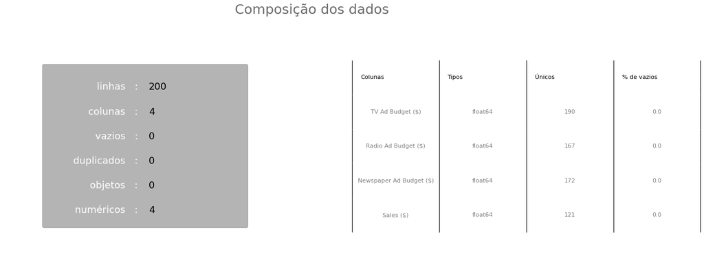

```python
diag_fun(dataset)
```

- Uma análise inicial dos dados demonstra que não há falta de dados e nem há dados repetidos, facilitando assim o tratamento de dados, sendo somente necessário o estudo das correlações dos dados.

## Análise Exploratória dos dados

- Aqui será feita uma exploração dos dados, onde será possível ver como esses dados são e como é sua correlação com o alvo.
- Para isso foram criadas duas funções que irão retornar imagens gráficas onde será possível fazer uma análise desses dados.

### Função

```python
def vis_num(df):
  """
  Modelo retorna um subplot dentro do subplot com o box e o histograma
  para os dados numéricos.
  """

# ========================= Configurações =========================
  fig = plt.figure(figsize=(20, 13))
  outer = gridspec.GridSpec(2, 2, wspace=0.3, hspace=0.2) # Tamanho de imagem.
  rows = 4 #Linhas
  cols = 2 #Colunas
  fig.suptitle('Análise da Distribuição dos Dados', fontsize=30, color='dimgrey') # Título da figura.

# ========================= Plotagem ==============================
  flierprops = dict(marker='x', markerfacecolor='r', markersize=4,
                  linestyle='none', markeredgecolor='gold') # Ajustes de como os outliers serão mostrados.

  for i in range(0,rows,2): # Loop para passar por cada Coluna e Linhas.
    for j in range(cols):
      # ---------------- Plotagem do BoxPlot --------------------
      try:
        inner = gridspec.GridSpecFromSubplotSpec(2, 1,
                          subplot_spec=outer[i+j], wspace=0.1, hspace=0)  # Criando 2 espaços na posição gráfica.

        nome = df.select_dtypes(include=np.number).iloc[:,i+j].name # Extrair qual coluna será mostrada.
        ax = plt.Subplot(fig, inner[0]) # Axis .
        fig.add_subplot(ax) # Adicionar o axis na figura.

        box = sns.boxplot(data=df, # Plotagem Gráfica
                          orient='h',
                          x = nome,
                          ax=ax, width=.3, color='lightyellow', flierprops=flierprops)


        box.axis('off') # Desativar barras de eixo.
        box.set_title(f'{nome}',horizontalalignment='left', x=0,fontsize=18,color='dimgrey') # Título.
         # ------= Plotagem dos quantiles.
        quantiles = df[nome].quantile([0.25, 0.75]).values.tolist() # Separação dos quantiles.
        LI = quantiles[0] - ((quantiles[1] - quantiles[0])*1.5)
        LS = quantiles[1] + ((quantiles[1] - quantiles[0])*1.5)
        if LI < df[nome].min():
          LI = df[nome].min()
        if LS > df[nome].max():
          LS = df[nome].max()

        for ix in [int(LI),int(LS)]: # Plotar no gráfico.
          box.annotate(round(ix,2), xy=(ix, 0.22), fontsize=12, color='black')
        for ix in quantiles:
          box.annotate(round(ix,2), xy=(ix, 0.22), fontsize=12, color='black')
      except:
        pass

    for j in range(cols):
      # ---------------- Plotagem do Histograma -------------------
      try:
          inner = gridspec.GridSpecFromSubplotSpec(2, 1,
                            subplot_spec=outer[i+j], wspace=0.1, hspace=0) # Criando 2 espaços na posição gráfica.

          nome = df.select_dtypes(include=np.number).iloc[:,i+j].name # Selecionar coluna a ser trabalhada.

          ax = plt.Subplot(fig, inner[1]) # Axis.
          fig.add_subplot(ax) # Adicionar o axis na figura.

          hist = sns.histplot(data=df, x = nome,color='lightyellow') # Plotagem Histograma.

          # ---------- Configurações de axis.
            # Desativar Barras de eixo.
          hist.spines['top'].set_visible(False)
          hist.spines['right'].set_visible(False)
            # Definir Cor das Barras de eixo.
          hist.spines['left'].set_color('darkgrey')
          hist.spines['bottom'].set_color('darkgrey'),
            # Parâmetros do tick.
          hist.tick_params(axis='both', colors='darkgrey')
          hist.set(xlabel='', ylabel='')



      except:
        pass
  return plt.show()
```

```python
def corre(df):
  """
  Modelo Gráfico com a funçaõ de avaliar a dispersão dos dados comparando dois dados numéricos.

  """

# ============== Configuração ==================
  figura = plt.figure(figsize=(25,8.3)) # Criando Figura.
  tamanho = (1,3)
  figura.suptitle('Correlação das Features com o Alvo (Sales $)', fontsize=30, color='grey', verticalalignment='center') # Título.
  plt.subplots_adjust(top=0.8) # Ajuste da Imagem
# ============== Plontagem =====================
  c = 0 # Contagem.
  for coluna in df.iloc[:,:3]: # Loops para os dados independentes.
    pos = (0,c)
    ax = plt.subplot2grid(tamanho, pos) # Axis.

    line = sns.regplot( # Criação gráfica
        data=df,
        y = coluna,
        x = df.iloc[:,-1].name,
        ci=95,
        order=2,
        color='lightsteelblue',
        line_kws={"color": "dimgrey"}
                )
    # ----------- Configuração das barras de eixo.
      # Desativar.
    line.spines['top'].set_visible(False)
    line.spines['right'].set_visible(False),
      # Cor.
    line.spines['left'].set_color('darkgrey')
    line.spines['bottom'].set_color('darkgrey')
    line.tick_params(axis='both', colors='darkgrey')
      # Ajustes.
    line.set_ylabel('Total Investido', horizontalalignment='right', y=1.0, color='black')
    line.set_xlabel('Vendas $ ', horizontalalignment='left', x=0, fontsize=10, color='black')
    line.set_title(coluna,horizontalalignment='left', x=0, fontsize=16,color='grey')

    c +=1 # Adicionar elemento na contagem.
  return figura.show()
```

```python
def fea_gen_1(df):
  """
 Imagem criada para avaliar as features generations criadas no modelo.
  """

# ============= Configurações ====================
  tamanho = (2,2)
  figura = plt.figure(figsize=(20,15))
  figura.suptitle('Avaliação das divisões orçamentárias', fontsize=30, color='grey', verticalalignment='center')
  plt.subplots_adjust(top=0.89,
                      wspace = 0.5,
                      hspace = 0.3)

# ============= Plotagem ====================

# ---------- Barra ++++++++++++++++++++++++++++++++++++++++++++++++++++++++++++
  pos = (0,0)
  ax = plt.subplot2grid(tamanho, pos)
  items, valores = np.unique(df['Dif Alocado'], return_counts=True) # Duas listas contendo categórico e quantidade.

  barra = sns.countplot( # Plot Gráfico.
      data = df,
      y = 'Dif Alocado',
      palette = 'YlOrBr',
      order=items # Por em ordem.
  )
  c = 0 # Contador.
  for item,valor in zip(items,valores): # Plotar o valor no texto.
    barra.annotate(valor, xy=(valor, c),  verticalalignment='center',horizontalalignment='left',color='dimgrey', fontsize=13)
    c += 1 # Atualizar Contador.

  # ------  Configurações Eixo
        # Desativar.
  barra.spines['top'].set_visible(False)
  barra.spines['right'].set_visible(False),
    # Cor.
  barra.spines['left'].set_color('darkgrey')
  barra.spines['bottom'].set_color('darkgrey')
  barra.tick_params(axis='x', colors='darkgrey')
  barra.tick_params(axis='y', colors='black')
    # Ajustes
  barra.set_ylabel('Classes', horizontalalignment='right', y=1.0, color='grey')
  barra.set_xlabel('')
  barra.set_title('Divisão Orçamentária',horizontalalignment='center', fontsize=16,color='grey')
  texto = """Cada Classe está em ordem decrescente,
  ou seja, quem estiver em
  primeiro recebeu um valor
  maior do que o elemento a seguir. """
  barra.annotate(texto, xy=(100, 0), fontsize=10, verticalalignment='center',horizontalalignment='center',color='lightgrey')


# ---------- Dispersão ++++++++++++++++++++++++++++++++++++++++++++++++++++++++++++
  pos = (0,1)
  ax = plt.subplot2grid(tamanho, pos)

  disp = sns.scatterplot(
      data=df,
      x = 'Sales ($)',
      y = 'Budget Sum',
      hue='Dif Alocado'
  )
  # ------  Configurações Eixo
        # Desativar.
  disp.spines['top'].set_visible(False)
  disp.spines['right'].set_visible(False),
    # Cor.
  disp.spines['left'].set_color('darkgrey')
  disp.spines['bottom'].set_color('darkgrey')
  disp.tick_params(axis='both', colors='darkgrey')

  disp.set_title('Orçamento Total x Vendas',horizontalalignment='center', fontsize=16,color='grey')


# # ---------- Boxs ++++++++++++++++++++++++++++++++++++++++++++++++++++++++++++
  for con1, nome in enumerate(['Sales ($)','Budget Sum']):
    pos = (1,con1)
    ax = plt.subplot2grid(tamanho, pos)

    box = sns.boxplot(
        data = df,
        x = nome,
        y = 'Dif Alocado',
        palette = 'YlOrBr',
        order = items
    )

    # ------= Plotagem dos quantiles.
    for con0, elemento in enumerate(items): # Criar loop para mostrar no gráfico a posição de cada quantile.
      df_temporario = df.loc[df['Dif Alocado'] == elemento] # Filtrando os dados somente contendo a classe estudada.

      quantiles = df_temporario[nome].quantile([0.25, 0.75]).values.tolist() # Separação dos quantiles.
      LI = quantiles[0] - ((quantiles[1] - quantiles[0])*1.5) # Limite Inferior
      LS = quantiles[1] + ((quantiles[1] - quantiles[0])*1.5) # Limite Superior
      # Ajustes de posição do LS e LI
      if LI < df_temporario[nome].min():
        LI = df_temporario[nome].min()
      if LS > df_temporario[nome].max():
        LS = df_temporario[nome].max()
      elif LS <= df_temporario[nome].max():
        LS = df_temporario.loc[df_temporario['Sales ($)'] <= LS, 'Sales ($)'].max()

      for con, ix in enumerate([LI,LS]): # Plotar no gráfico.
        if con % 2 == 0: # Se par o plot vai a direita, se não a esquerda.
          h = 'right'
        else:
          h = 'left'
        box.annotate(round(ix,2), xy=(ix, con0+0.3), fontsize=8, color='dimgrey', horizontalalignment=h)
      for con, ix in enumerate(quantiles):
        mover = 0.05 # Ajuste para deslocar o texto.
        if con % 2 == 0:
          h = 'right'
          ixi = ix + (ix*-mover)
        else:
          h = 'left'
          ixi = ix + (ix*mover)
        box.annotate(round(ix,2), xy=(ixi, con0-0.3), fontsize=8, color='dimgrey', horizontalalignment=h, verticalalignment='bottom')


    # ------  Configurações Eixo
          # Desativar.
    box.spines['top'].set_visible(False)
    box.spines['right'].set_visible(False),
      # Cor.
    box.spines['left'].set_color('darkgrey')
    box.spines['bottom'].set_color('darkgrey')
    box.tick_params(axis='both', colors='darkgrey')
      # Ajustes.
    box.set_ylabel('Classes', horizontalalignment='right', y=1.0, color='black')
    box.set_xlabel(nome, horizontalalignment='left', x=0, fontsize=10, color='black')
    box.set_title(f'Divisão orçamentária x {nome} ',horizontalalignment='right', x=1, fontsize=16,color='grey')
    box.set_xlim([-df[nome].max()*0.05,df[nome].max()]) # Definir limites de X

  return figura.show()
```

### Análise

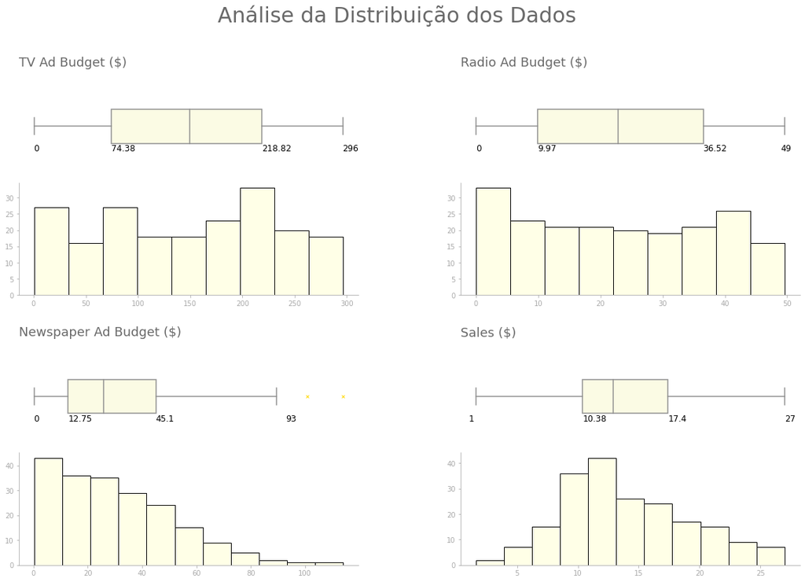

```python
vis_num(dataset)
```

- Orçamento da TV e da Rádio mantiveram uma próxima à distribuição uniforme sem uma presença de outliers.
- Já o orçamento dos jornais manteve uma distribuição do tipo exponencial, no qual o pico da quantidade dos valores é o limite dos dados e a partir do pico os valores vão decaindo. Com a leitura dos quartis é possível observar que, pelo menos, 75% do orçamento foi inferior a 45.1, chegando até 93, contendo dados como outliers (acima de 93)
- Fica claro que a TV apresenta um valor mais alto de investimento, enquanto os jornais estão em segundo lugar e por último temos o rádio, que apresenta um orçamento até 49.
- Analisando o alvo das predições (**Vendas**), observa-se que ele apresenta uma distribuição normal, isso sendo ótimo para o modelo de machine learning (evita possível viés). Pelo box vemos que 50% dos dados ficam entre 10.3 e 17.4

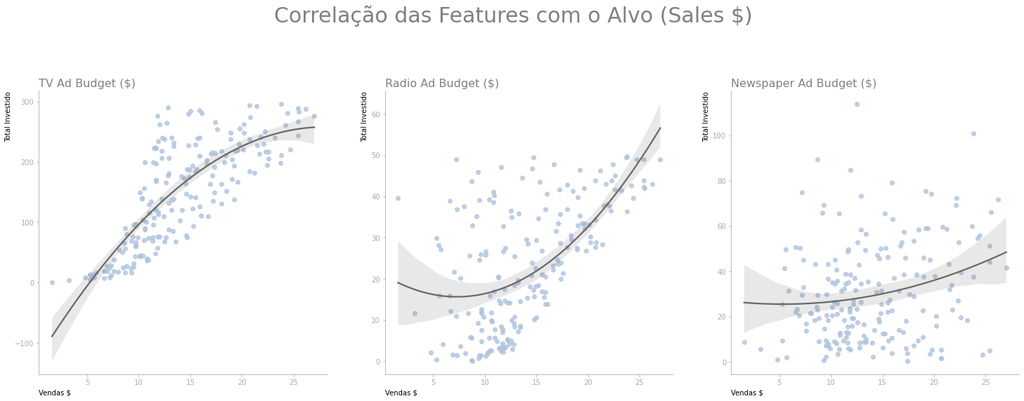

```python
corre(dataset)
```

**Investimento x Retorno**

- O orçamento investido para propaganda na Televisão foi o que apresentou o melhor desempenho de retorno, percebe-se isso por 2 motivos. Primeiro analisando a curva da regressão polinomial de grau 2, a curva é bem inclinada e curva, dando uma noção que quanto maior o investimento maior o retorno. O segundo motivo é a dispersão dos dados, percebe-se (principalmente se comparado aos outros dois) que os dados tendem a se concentrar mais próximos da linha da regressão.
- O orçamento investido para o rádio apresenta um desempenho acendente, como o da televisão, porém a dispersão nesse investimento é bem alta, isso se traduz que a certeza de retorno é bem menor, isso é visualmente possível observando a curva que tendem a fazer a decair nos valores baixos de venda, tanto que se trassarmos uma linha vertical no valor de 10 $ é possível observar uma dispersão total, onde temos valores investidos altos e baixos dando o mesmo retorno baixo. Porém, ele obteve um retorno com menos valor investido se comparado com os outros dois modelos.
- O orçamento investido para jornais foi o que apresentou o pior resultado se avaliado em investimento x retorno pelo fato de, mesmo seguindo em alta, a linha é próxima de ser plana. Ainda é possível observar uma concentração de dados do retorno de venda abaixo de 15 $

## Feature Generation

- Para extrair mais informações dos dados é possível aplicar o feature generation, que nada mais é do que a criação de dados a partir dos dados originais.
- Algumas informações podem ser obtidas do dataset original:
  - Total do orçamento investido
  - Criação de classes para comparar qual orçamento foi maior.
  - Porcentagem de cada orçamento sobre o valor total.

```python
# Orçamento Total.
dataset['Budget Sum'] = dataset.iloc[:,:3].sum(1)
```

```python
# Diferença de Orçamento.
categorico = []
for index, row in dataset.iterrows():
    a1 = row['TV Ad Budget ($)']
    a2 = row['Radio Ad Budget ($)']
    a3 = row['Newspaper Ad Budget ($)']
    if (a1 > a2) & (a1 > a3):

      if (a2 > a3):
        categorico.append('tv > radio > news')
      else:
        categorico.append('tv > news > radio')

    elif (a2> a1) & (a2>a3):
      if (a1 > a3):
        categorico.append('radio > tv > news')
      else:
        categorico.append('radio > news > tv')

    elif (a3 > a1) & (a3>a2):
      if (a2 > a3):
        categorico.append('news > radio > tv')
      else:
        categorico.append('news > tv > radio')

dataset['Dif Alocado'] = categorico
```

```python
# Porcentagem presente de cada orçamento
for i in dataset.iloc[:,:3]:
  dataset[f'Porcentagem {i}'] = (dataset[i]/dataset['Budget Sum'])*100
```

```python
dataset
```

|  | TV Ad Budget ($) | Radio Ad Budget ($) | Newspaper Ad Budget ($) | Sales ($) | Budget Sum | Dif Alocado | Porcentagem TV Ad Budget ($) | Porcentagem Radio Ad Budget ($) | Porcentagem Newspaper Ad Budget ($) |
| --- | --- | --- | --- | --- | --- | --- | --- | --- | --- |
| 1 | 230.1 | 37.8 | 69.2 | 22.1 | 337.1 | tv > news > radio | 68.258677 | 11.213290 | 20.528033 |
| 2 | 44.5 | 39.3 | 45.1 | 10.4 | 128.9 | news > tv > radio | 34.522886 | 30.488751 | 34.988363 |
| 3 | 17.2 | 45.9 | 69.3 | 9.3 | 132.4 | news > tv > radio | 12.990937 | 34.667674 | 52.341390 |
| 4 | 151.5 | 41.3 | 58.5 | 18.5 | 251.3 | tv > news > radio | 60.286510 | 16.434540 | 23.278949 |
| 5 | 180.8 | 10.8 | 58.4 | 12.9 | 250.0 | tv > news > radio | 72.320000 | 4.320000 | 23.360000 |
| ... | ... | ... | ... | ... | ... | ... | ... | ... | ... |
| 196 | 38.2 | 3.7 | 13.8 | 7.6 | 55.7 | tv > news > radio | 68.581688 | 6.642729 | 24.775583 |
| 197 | 94.2 | 4.9 | 8.1 | 9.7 | 107.2 | tv > news > radio | 87.873134 | 4.570896 | 7.555970 |
| 198 | 177.0 | 9.3 | 6.4 | 12.8 | 192.7 | tv > radio > news | 91.852621 | 4.826155 | 3.321225 |
| 199 | 283.6 | 42.0 | 66.2 | 25.5 | 391.8 | tv > news > radio | 72.383869 | 10.719755 | 16.896376 |
| 200 | 232.1 | 8.6 | 8.7 | 13.4 | 249.4 | tv > news > radio | 93.063352 | 3.448276 | 3.488372 |

200 rows × 9 columns

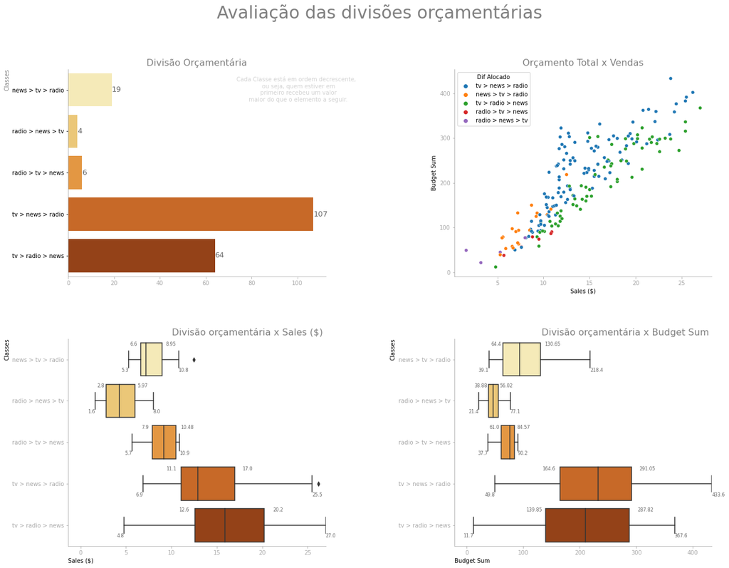

```python
fea_gen_1(dataset)
```

- O gráfico de dispersão que compara vendas x Orçamento demonstra que há uma tendência de maior investimento ser igual a mais venda.
- As divisões orçamentárias se concentraram em **TV > News > Radio** e **TV > Radio > News** compondo quase todos os dados presentes.
- Voltando ao gráfico de dispersão é possível observar que a divisão de **TV > News > Radio** apresenta um valor mais elevado do orçamento gasto do que **TV > Radio > News** e ambos apresentando o mesmo resultado de vendas.
- Quando Olhamos para os gráficos de caixa ai que a diferença de ambos aparenta ser significativa. No primeiro gráfico é possível observar como cada classe de divisão orçamentária se saiu com as vendas, já na segunda é possível ver o valor total do orçamento para essa divisão. O modelo **TV > Radio > News** apresentou um resultado mais amplo, sendo em torno de 70% dos dados presentes acima da mediana do modelo **TV > News > Radio**, mas o que isso significa? Significa que o modelo **TV > News > Radio** tem pelo menos 50% dos dados de venda acima de ~= 12, já o modelo **TV > Radio > News** apresenta em torno de 70% dos dados acima de ~= 12. Agora fazendo essa comparação para o gráfico do total orçamentário, os valores investidos nesse arranjo dos custos foi menor para o modelo **TV > Radio > News**. Isso significa menos gastos e mais economia para a empresa. Por último, mas não menos importante, é possível observar no primeiro gráfico de caixa na classe **TV > News > Radio** um outlier, isso significa que o melhor desempenho para essa organização é em torno de 25.5 acima disso já é um ponto fora da normalidade, enquanto no modelo **TV > Radio > News** o range abrange até o valor máximo registrado.
- Em relação as outras classes? Elas representam aproximadamente 15% dos dados presentes, onde o modelo **News > TV > Radio** apresenta o pior resultado, isso por que no gráfico de dispersão esse modelo apresenta um orçamento mais alto que os outros modelos que obtiveram os mesmo resultados. Isso fica mais claro quando olhamos para o gráfico de caixas, onde podendo chegar a ter um orçamento máximo até maior que a mediana do modelo **TV > Radio > News** seu resultado de vendar foi bem inferior. Já as outras duas classes se saíram muito bem, apresentando os menores orçamentos totais, mas com um range de retorno bem satisfatório.

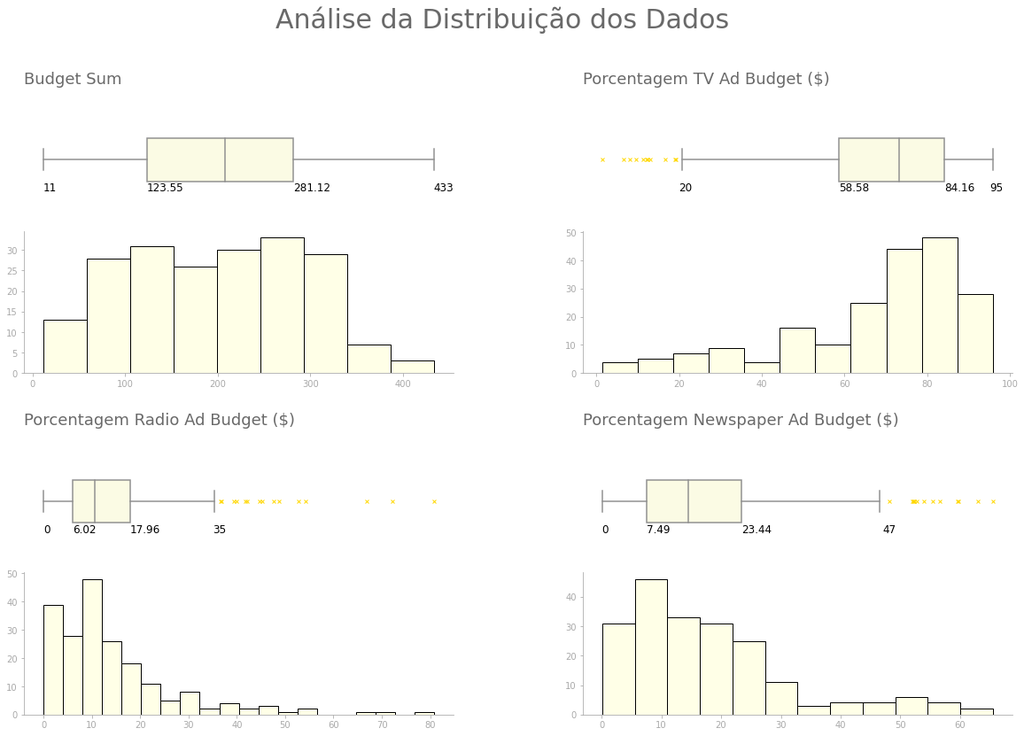

```python
vis_num(dataset[['Budget Sum','Porcentagem TV Ad Budget ($)','Porcentagem Radio Ad Budget ($)','Porcentagem Newspaper Ad Budget ($)']])
```

- A imagem montada acima foi elaborada para dar uma noção de como está a distribuição do orçamento e a porcentagem de cada tipo de anúncio.
- A Total orçamentário apresenta uma distribuição próxima ao normal, podendo ser confundida até com uma uniforme.(analisando o dado visualmente, mas pode ser feito um cálculo de simetria e curtose para verificar como está essa distribuição)
- Os 3 tipos de anúncios apresentam uma distribuição gamma, ou seja, há um viés muito forte nos 3, sendo o jornal e o rádio a esquerda e a televisão a direita, ou seja, a maior parte dos orçamentos está voltada para a televisão, enquanto para o rádio o máximo alcançado é de 35%, sendo acima disso já considerado outliers. No caso do jornal até 47% do orçamento foi registrado como máximo na distribuição dos dados, acima disso já é um outlier.
- Para a televisão há, pelo menos (segundo a distribuição) 20% do orçamento designado para esse anúncio, sendo abaixo disso considerado um outlier, podendo chegar até 95%, sendo praticamente o orçamento total para anúncios.

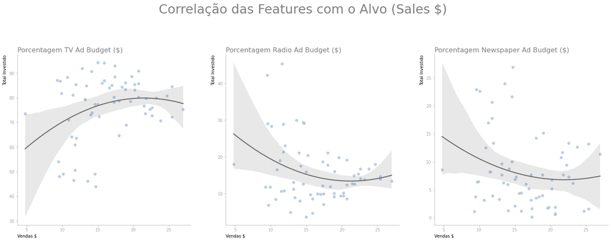

```python
corre(dataset.loc[dataset['Dif Alocado'] == 'tv > radio > news', ['Porcentagem TV Ad Budget ($)', 'Porcentagem Radio Ad Budget ($)',
       'Porcentagem Newspaper Ad Budget ($)', 'Sales ($)']])
```

- Na imagem acima temos os dados com o filtro do modelo: **tv > radio > news** no qual apresenta a porcentagem de cada divisão de orçamento presente e o resultado disso em vendas.
- Do orçamento para a TV o gráfico demonstra que a grande maioria dos dados se concentram acima do valor de 70% tendo a curva indicando a tendência de alta, junto ao aumento da presença desse orçamento no total. Tudo isso indica que a concentração de investimento nesse setor é bem interessante para bons resultados.
- Já no orçamento do rádio é possível observar que valores abaixo de 20% renderam um melhor retorno, o crescimento final da curva demonstra esse entendimento.
- O anúncio no jornal tem uma faixa de erro muito larga, e aponta que um menor investimento nesse orçamento traz um retorno maior, porém temos uma grande concentração de dados abaixo dos 10% que acabam sendo bem dispersos, mas ainda assim no final demonstra que um investimento até 15% pode ser válido.

# Previsões

## Machine Learning

- A análise exploratória dos dados permitiu ter uma compreensão do comportamento dos dados e da influência das variáveis independentes na variável dependente. Agora o próximo passo é desenvolver um modelo preditivo que retorne o provável saldo de vendas obtidos com essa combinação orçamentária.
- O modelo irá seguir a seguinte estrutura:
  - Será feito o tratamento dos dados: (Categóricos para numéricos e normalização dos dados numéricos).
  - Para evitar certos viés nos dados, será utilizado o modelo de validação cruzada que, em resumo, divide os dados em n partes iguais de treino e teste, garantindo assim que todo o dataset seja usado tanto para testar como para treinar.
  - Para o modelo de previsão será utilizado dois modelos, sendo um modelo mais simples de regressão, no caso a **Regressão Polinomial** e um dos modelos mais famosos da atualidade que é a **Rede Neural**. A aplicabilidade de ambos são mais distintas, visto que a rede neural apresenta melhores resultados quando se tem grandes quantidades de dados, além de ser mais utilizada quando os dados são imagens, áudios e vídeos, já o polinomial pode ser usado para aplicações mais simples, com dados menores e menos complexos, como o caso desses dados trabalhados aqui.
  - A avaliação de resultado será feita utilizando pela média da raiz quadrada do erro ao quadrado, sendo um dos modelos de erros que mais gosto por dar peso aos valores de erro mais altos, sendo assim demonstra um valor mais próximo à realidade do que simplesmente uma média. Além disso, será também levado em consideração o tempo de execução e o R2 de cada modelo, sendo o R2 definido como a proporção da variância do alvo que é possível prever através das variáveis independentes.

```python
dataset.head()
```

|  | TV Ad Budget ($) | Radio Ad Budget ($) | Newspaper Ad Budget ($) | Sales ($) | Budget Sum | Dif Alocado | Porcentagem TV Ad Budget ($) | Porcentagem Radio Ad Budget ($) | Porcentagem Newspaper Ad Budget ($) |
| --- | --- | --- | --- | --- | --- | --- | --- | --- | --- |
| 1 | 230.1 | 37.8 | 69.2 | 22.1 | 337.1 | tv > news > radio | 68.258677 | 11.213290 | 20.528033 |
| 2 | 44.5 | 39.3 | 45.1 | 10.4 | 128.9 | news > tv > radio | 34.522886 | 30.488751 | 34.988363 |
| 3 | 17.2 | 45.9 | 69.3 | 9.3 | 132.4 | news > tv > radio | 12.990937 | 34.667674 | 52.341390 |
| 4 | 151.5 | 41.3 | 58.5 | 18.5 | 251.3 | tv > news > radio | 60.286510 | 16.434540 | 23.278949 |
| 5 | 180.8 | 10.8 | 58.4 | 12.9 | 250.0 | tv > news > radio | 72.320000 | 4.320000 | 23.360000 |

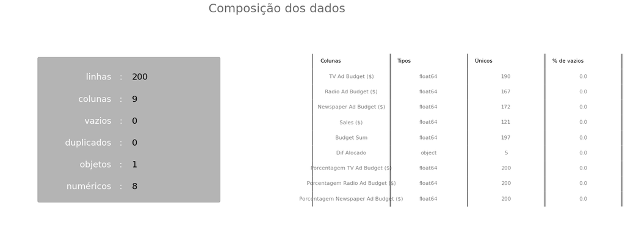

```python
diag_fun(dataset)
```

# Tratamento dos dados

```python
dataset = dataset.reset_index(drop=True)
data = dataset.copy() # Fazendo uma cópia para manter o original sem alterações

# Transformar categóricos em numéricos
colunas = dataset.select_dtypes(include='object').columns
for nome in colunas:
  data[nome] = LabelEncoder().fit_transform(data[nome])

# Transformar escala numérica.
alvo = data.pop('Sales ($)') # Separar alvo do dataset

data.iloc[:,:] = MinMaxScaler().fit_transform(data) # Dados transformados.
data.head()
```

|  | TV Ad Budget ($) | Radio Ad Budget ($) | Newspaper Ad Budget ($) | Budget Sum | Dif Alocado | Porcentagem TV Ad Budget ($) | Porcentagem Radio Ad Budget ($) | Porcentagem Newspaper Ad Budget ($) |
| --- | --- | --- | --- | --- | --- | --- | --- | --- |
| 0 | 0.775786 | 0.762097 | 0.605981 | 0.771273 | 0.75 | 0.707818 | 0.138750 | 0.312432 |
| 1 | 0.148123 | 0.792339 | 0.394019 | 0.277791 | 0.00 | 0.350512 | 0.377260 | 0.533645 |
| 2 | 0.055800 | 0.925403 | 0.606860 | 0.286087 | 0.00 | 0.122460 | 0.428969 | 0.799111 |
| 3 | 0.509976 | 0.832661 | 0.511873 | 0.567907 | 0.75 | 0.623382 | 0.203357 | 0.354515 |
| 4 | 0.609063 | 0.217742 | 0.510994 | 0.564826 | 0.75 | 0.750832 | 0.053455 | 0.355755 |